# Final Project

## 5b. Check for outliers, IQR, and summarize the statistics.

```r
cat("--Summary of backers count--")
```

```
## --Summary of backers count--
```

```r
summary(dataFinal$backers_count)
```

```
##    Min. 1st Qu.  Median    Mean 3rd Qu.    Max.
##     0.0     5.0    35.0   160.6   104.0 26406.0
```

```r
cat("Outliers count: ",length(sort(boxplot.stats(dataFinal$backers_count)$out)))
```

```
## Outliers count:  1013
```

```r
cat("IQR: ", IQR(dataFinal$backers_count))
```

```
## IQR:  99
```

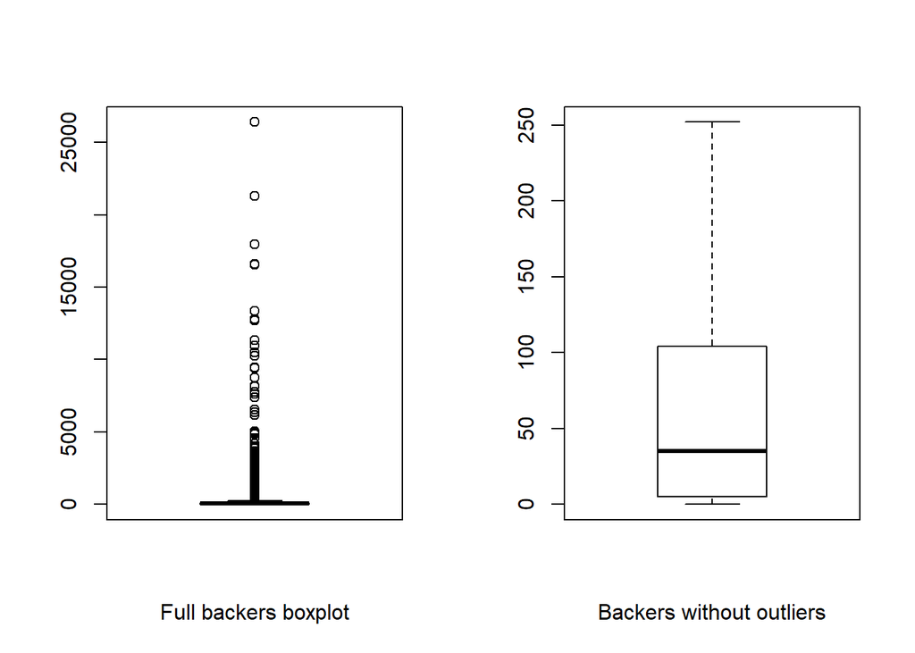

```r
par(mfrow = c(1, 2))
boxplot(dataFinal$backers_count,xlab="Full backers boxplot")
boxplot(dataFinal$backers_count,xlab="Backers without outliers",outline=FALSE)
```

```r
cat("--Summary of goal $--")
```

```
## --Summary of goal $--
```

```r
summary(dataFinal$goal)
```

```
##      Min.   1st Qu.    Median      Mean   3rd Qu.      Max.
##       105      1800      5000     59790     12366 100000000
```

```r
cat("Outliers count: ",length(sort(boxplot.stats(dataFinal$goal)$out)))
```

```
## Outliers count:  1166
```

```r
cat("IQR: ", IQR(dataFinal$goal))
```

```
## IQR:  10565.5
```

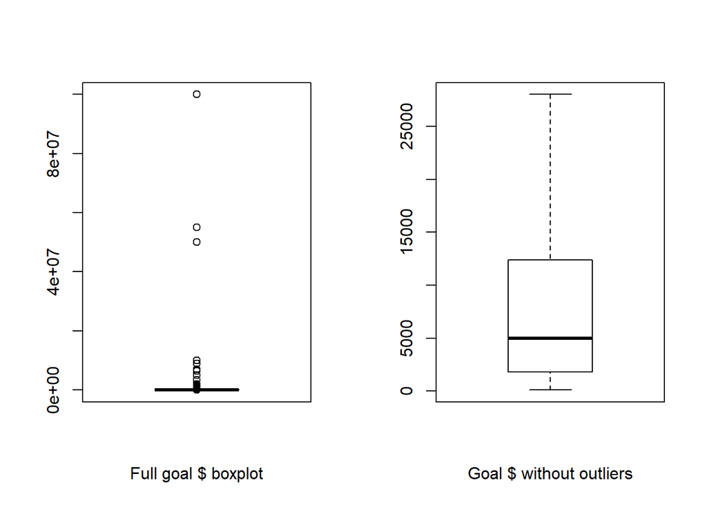

```r
par(mfrow = c(1, 2))
boxplot(dataFinal$goal,xlab="Full goal $ boxplot")
boxplot(dataFinal$goal,xlab="Goal $ without outliers",outline=FALSE)
```

```r
cat("--Summary of pledged $--")
```

```
## --Summary of pledged $--
```

```r
summary(dataFinal$pledged)
```

```
##    Min. 1st Qu.  Median    Mean 3rd Qu.    Max.
##       0     210    2217   16403    8211 7850867
```

```r
cat("Outliers count: ",length(sort(boxplot.stats(dataFinal$pledged)$out)))
```

```
## Outliers count:  1075
```

```r
cat("IQR: ", IQR(dataFinal$pledged))
```

```
## IQR:  8001
```

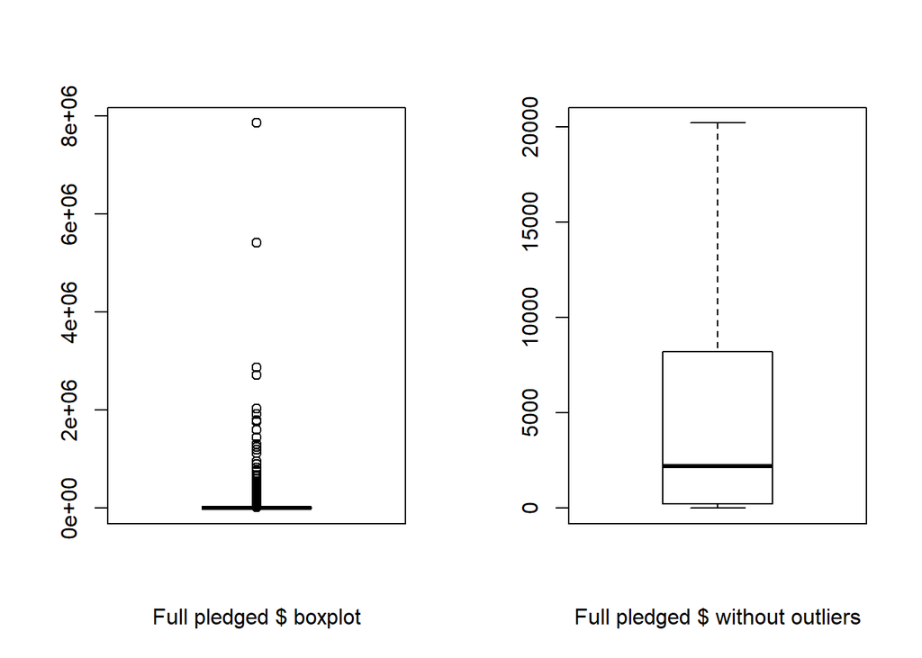

```r
par(mfrow = c(1, 2))
boxplot(dataFinal$pledged,xlab="Full pledged $ boxplot")
boxplot(dataFinal$pledged,xlab="Full pledged $ without outliers",outline=FALSE)
```

```r
cat("--Summary of % raised--")
```

```
## --Summary of % raised--
```

```r
summary(dataFinal$pReached)
```

```
##     Min.  1st Qu.   Median     Mean  3rd Qu.     Max.
##     0.00     0.01   103.66   158.30   127.54 54054.12
```

```r
cat("Outliers count: ",length(sort(boxplot.stats(dataFinal$pReached)$out)))
```

```
## Outliers count:  660
```

```r
cat("IQR: ", IQR(dataFinal$pReached))
```

```
## IQR:  127.5319
```

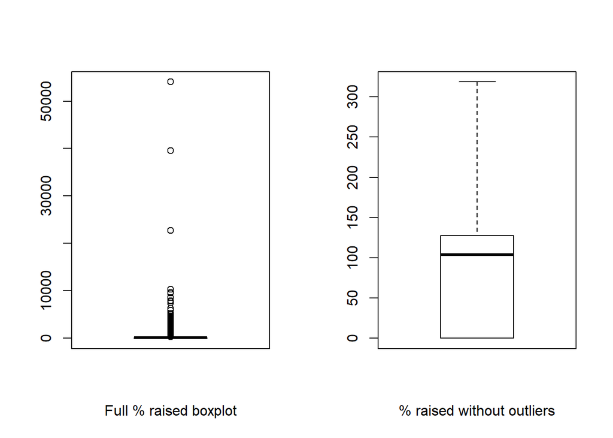

```r
par(mfrow = c(1, 2))
boxplot(dataFinal$pReached,xlab="Full % raised boxplot")
boxplot(dataFinal$pReached,xlab="% raised without outliers",outline=FALSE)
```

## 5c. Disect your variables in a way that will help you with your analysis.

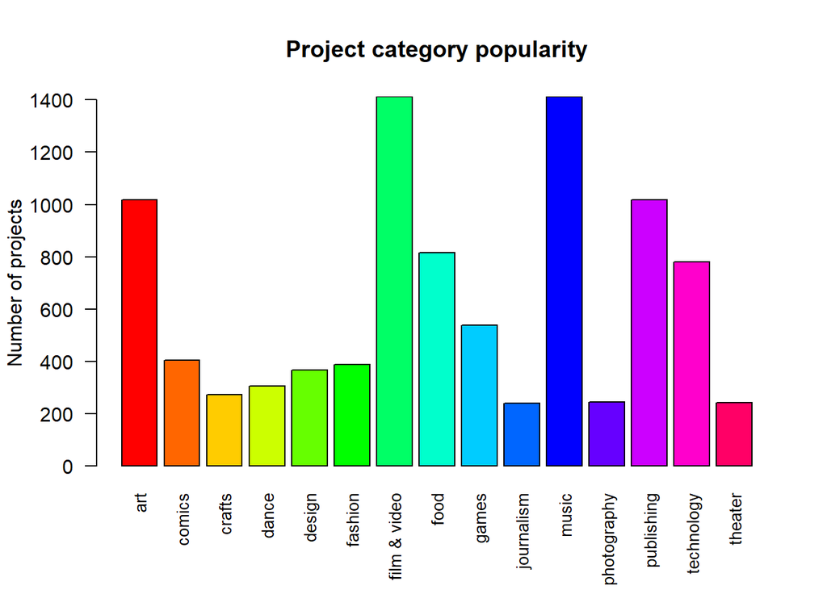

```r
# Categorizing the data by type of project

barplot(table(dataFinal$category),col= rainbow(15),las = 2,cex.names = .85,horiz = FALSE,beside=TRUE, xpd = FALSE, main="Project category popularity", ylab="Number of projects")
```

## 5d. Determine the distribution (if any that your data follow, experimentally and theoretically)

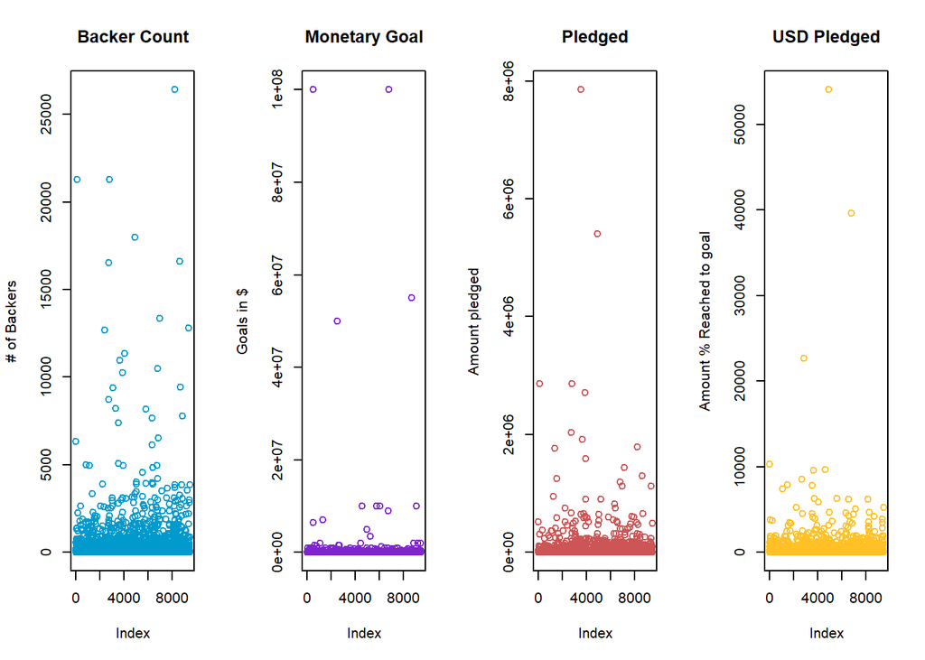

```r
par(mfrow = c(1, 4)) #Creates a 1 x 4 picture of the graphs

plot(dataFinal$backers_count, ylab = "# of Backers", main = "Backer Count", col = "deepskyblue3")
plot(dataFinal$goal, ylab = "Goals in $", main = "Monetary Goal", col = "purple3")
plot(dataFinal$pledged, ylab = "Amount pledged", main = "Pledged", col = "indianred3")
plot(dataFinal$pReached, ylab = "Amount % Reached to goal", main = "USD Pledged", col = "goldenrod1")
```

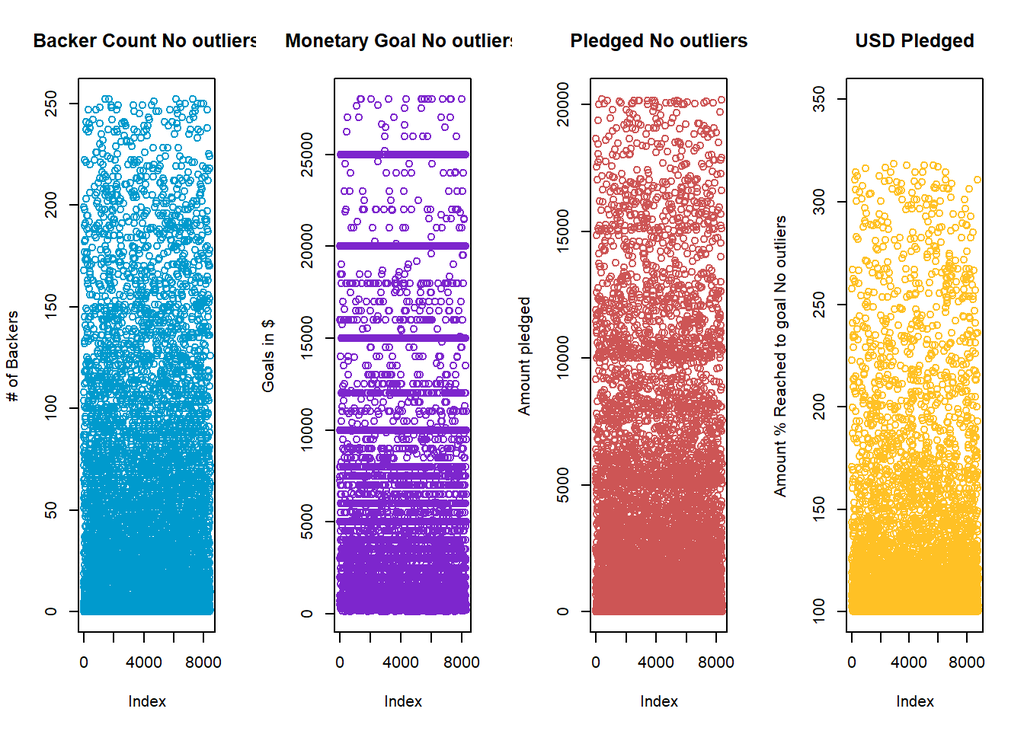

```r
par(mfrow = c(1, 4)) #Creates a 1 x 4 picture of the graphs of no outliers

plot(dataFinal$backers_count[which(!dataFinal$backers_count %in% boxplot.stats(dataFinal$backers_count)$out)], ylab = "# of Backers", main = "Backer Count No outliers", col = "deepskyblue3")
plot(dataFinal$goal[which(!dataFinal$goal %in% boxplot.stats(dataFinal$goal)$out)], ylab = "Goals in $", main = "Monetary Goal No outliers", col = "purple3")
plot(dataFinal$pledged[which(!dataFinal$pledged %in% boxplot.stats(dataFinal$pledged)$out)], ylab = "Amount pledged", main = "Pledged No outliers", col = "indianred3")
plot(dataFinal$pReached[which(!dataFinal$pReached %in% boxplot.stats(dataFinal$pReached)$out)], ylab = "Amount % Reached to goal No outliers", main = "USD Pledged", col = "goldenrod1",ylim=c(100,350))
```

#The quantative variables do not follow any distributions.

```r
summary(dataFinal$backers_count)
```

```
##    Min. 1st Qu.  Median    Mean 3rd Qu.    Max.
##     0.0     5.0    35.0   160.6   104.0 26406.0
```

```r
summary(dataFinal$goal)
```

```
##      Min.   1st Qu.    Median      Mean   3rd Qu.      Max.
##       105      1800      5000     59790     12366 100000000
```

```r
summary(dataFinal$pledged)
```

```
##    Min. 1st Qu.  Median    Mean 3rd Qu.    Max.
##       0     210    2217   16403    8211 7850867
```

```r
summary(dataFinal$dataFinal$pReached)
```

```
## Length  Class   Mode
##      0   NULL   NULL
```

Our main focus for this project was how the category affected the success of a project and if it’s a good predictor for success. We began this analysis by filtering our data set into a “Successful” and “Failed” section. Any project that hit 100 percent of its goal or higher fell under success. Any that scored under 100% fell under failure. Live and canceled projects were not included in our analysis because the focus was on projects that had been successful or had failed. As such, projects that fell under the status of “Live” or “Canceled” were removed from our data set.

## 5e. Show your analysis in both tables/charts and visually (histograms, qqnorm plots, boxplots etc.Statistical Modeling)

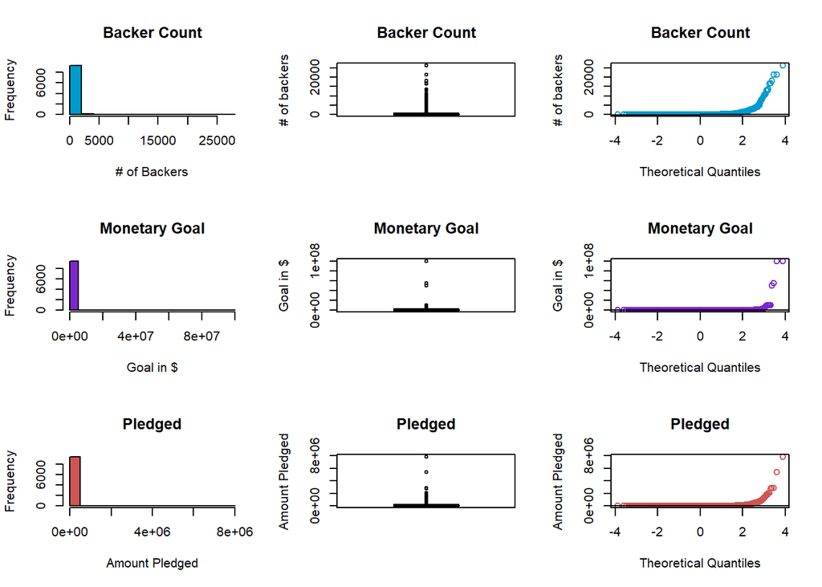

```r
par(mfrow = c(3,3)) #Creates a 3 x 3 picture of the graphs

#Backer Count
hist(dataFinal$backers_count, xlab = "# of Backers", main = "Backer Count", col = "deepskyblue3")
boxplot(dataFinal$backers_count, ylab = "# of backers", main = "Backer Count", col = "deepskyblue3")
qqnorm(dataFinal$backers_count, ylab = "# of backers", main = "Backer Count", col = "deepskyblue3")
qqline(dataFinal$backers_count)

#Goal
hist(dataFinal$goal, xlab = "Goal in $", main = "Monetary Goal", col = "purple3")
boxplot(dataFinal$goal, ylab = "Goal in $", main = "Monetary Goal", col = "purple3")
qqnorm(dataFinal$goal, ylab = "Goal in $", main = "Monetary Goal", col = "purple3")
qqline(dataFinal$goal)

#Pledged
hist(dataFinal$pledged, xlab = "Amount Pledged", main = "Pledged", col = "indianred3")
boxplot(dataFinal$pledged, ylab = "Amount Pledged", main = "Pledged", col = "indianred3")
qqnorm(dataFinal$pledged, ylab = "Amount Pledged", main = "Pledged", col = "indianred3")
qqline(dataFinal$pledged)
```

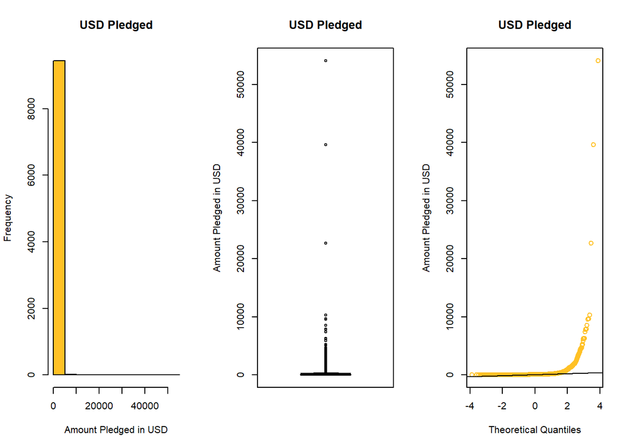

```r
par(mfrow = c(1, 3)) #Creates a 1 x 3 picture of the graphs

#USD Pledged
hist(dataFinal$pReached, xlab = "Amount Pledged in USD", main = "USD Pledged", col = "goldenrod1")
boxplot(dataFinal$pReached, ylab = "Amount Pledged in USD", main = "USD Pledged", col = "goldenrod1")
qqnorm(dataFinal$pReached, ylab = "Amount Pledged in USD", main = "USD Pledged", col = "goldenrod1")
qqline(dataFinal$pReached)
```

## 6) Determine correlations, do correlation comparisons (technically and visually ) use both plots or pairs for your graphical representations. Split your graphs in ways that will help you to conclude and infer based on your model.

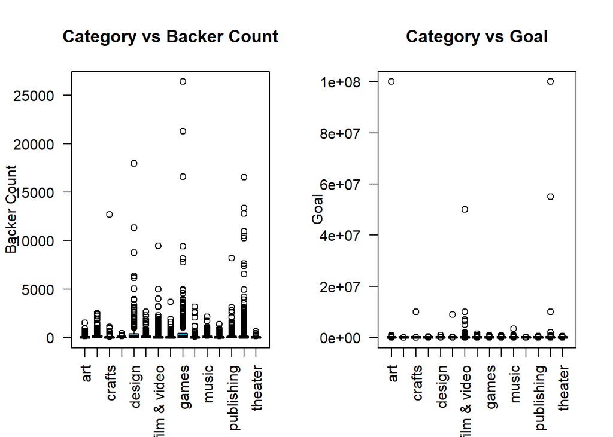

```r
# TODO: Change to by category or leave as ID.

par(mfrow = c(1, 2)) #Creates a 1 x 2 picture of the graphs
plot(dataFinal$category, dataFinal$backers_count, xlab = "", ylab = "Backer Count", main = "Category vs Backer Count", col = "deepskyblue3",las =2, cex.names = .5)
plot(dataFinal$category, dataFinal$goal, xlab = "", ylab = "Goal", main = "Category vs Goal", col = "purple3",las =2,cex.names = .5)
```

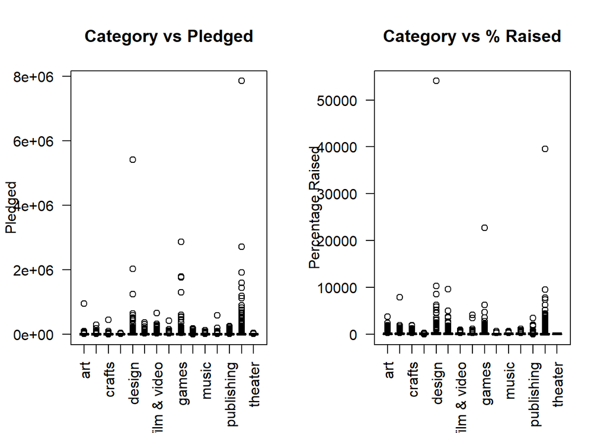

```r
par(mfrow = c(1, 2))
plot(dataFinal$category, dataFinal$pledged, xlab = "", ylab = "Pledged", main = "Category vs Pledged", col = "indianred3",las =2,cex.names = .5)
plot(dataFinal$category, dataFinal$pReached, xlab = "", ylab = "Percentage Raised",cex.names = .25, main = "Category vs % Raised", col = "goldenrod1",las =2,beside=TRUE, xpd = FALSE)
```

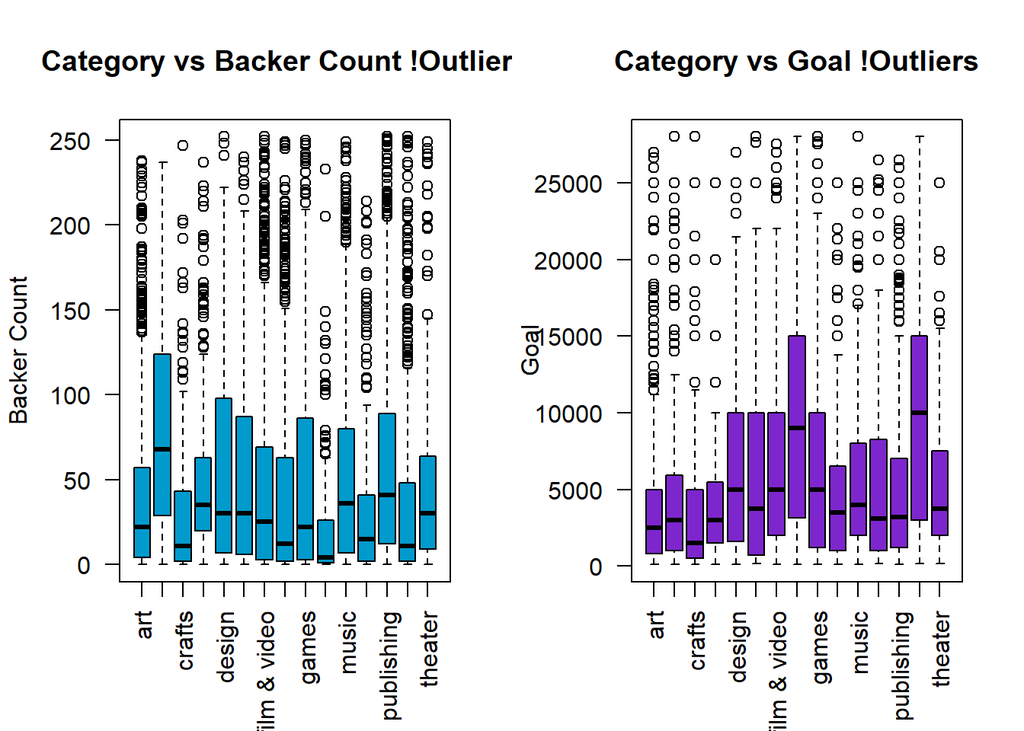

```r
par(mfrow = c(1, 2)) #Creates a 1 x 2 picture of the graphs
plot(dataFinal$category[which(!dataFinal$backers_count %in% boxplot.stats(dataFinal$backers_count)$out)], dataFinal$backers_count[which(!dataFinal$backers_count %in% boxplot.stats(dataFinal$backers_count)$out)], xlab = "", ylab = "Backer Count", main = "Category vs Backer Count !Outliers", col = "deepskyblue3",las =2, cex.names = .5)
plot(dataFinal$category[which(!dataFinal$goal %in% boxplot.stats(dataFinal$goal)$out)], dataFinal$goal[which(!dataFinal$goal %in% boxplot.stats(dataFinal$goal)$out)], xlab = "", ylab = "Goal", main = "Category vs Goal !Outliers", col = "purple3",las =2,cex.names = .5)
```

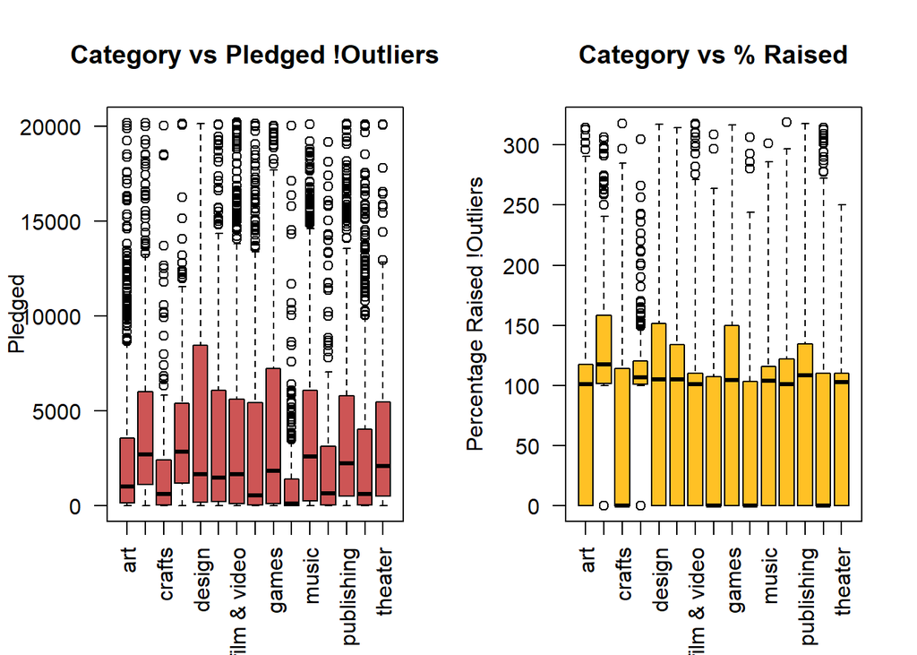

```r
par(mfrow = c(1, 2))
plot(dataFinal$category[which(!dataFinal$pledged %in% boxplot.stats(dataFinal$pledged)$out)],
     dataFinal$pledged[which(!dataFinal$pledged %in% boxplot.stats(dataFinal$pledged)$out)], xlab = "", ylab = "Pledged", main = "Category vs Pledged !Outliers", col = "indianred3",las =2,cex.names = .5)
plot(dataFinal$category[which(!dataFinal$pReached %in% boxplot.stats(dataFinal$pReached)$out)], dataFinal$pReached[which(!dataFinal$pReached %in% boxplot.stats(dataFinal$pReached)$out)], xlab = "", ylab = "Percentage Raised !Outliers",cex.names = .25, main = "Category vs % Raised", col = "goldenrod1",las =2,beside=TRUE, xpd = FALSE)
```

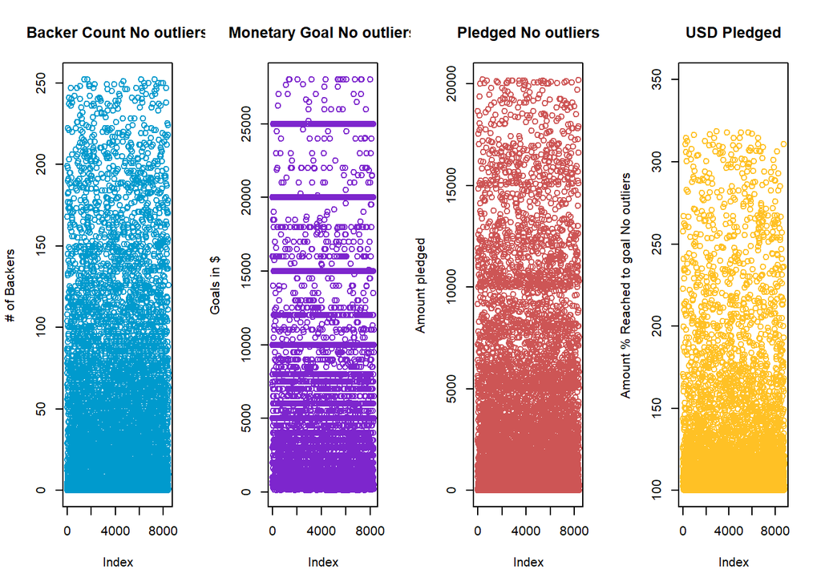

```r
par(mfrow = c(1, 4)) #Creates a 1 x 2 picture of the graphs of no outliers

plot(dataFinal$backers_count[which(!dataFinal$backers_count %in% boxplot.stats(dataFinal$backers_count)$out)], ylab = "# of Backers", main = "Backer Count No outliers", col = "deepskyblue3")
plot(dataFinal$goal[which(!dataFinal$goal %in% boxplot.stats(dataFinal$goal)$out)], ylab = "Goals in $", main = "Monetary Goal No outliers", col = "purple3")
plot(dataFinal$pledged[which(!dataFinal$pledged %in% boxplot.stats(dataFinal$pledged)$out)], ylab = "Amount pledged", main = "Pledged No outliers", col = "indianred3")
plot(dataFinal$pReached[which(!dataFinal$pReached %in% boxplot.stats(dataFinal$pReached)$out)], ylab = "Amount % Reached to goal No outliers", main = "USD Pledged", col = "goldenrod1",ylim=c(100,350))
```

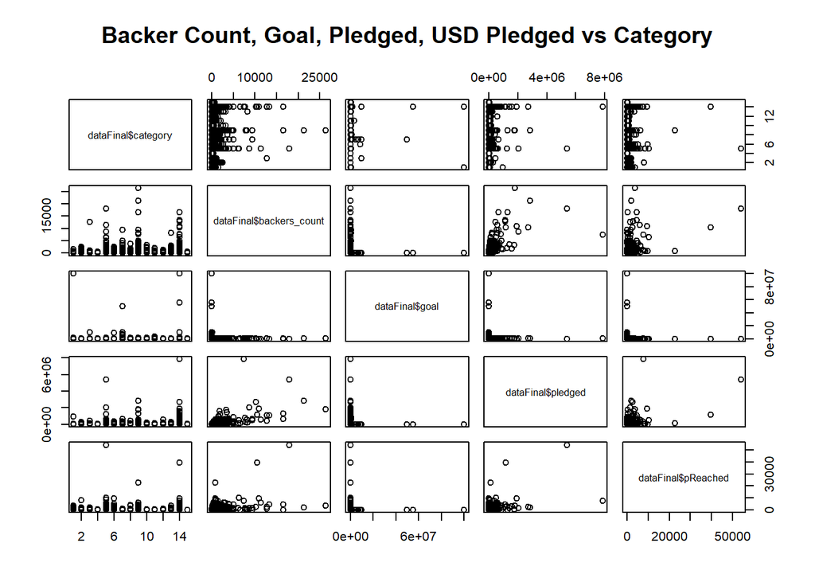

```r
# plots by cattegory
pairs(dataFinal$category~dataFinal$backers_count + dataFinal$goal + dataFinal$pledged + dataFinal$pReached, main = "Backer Count, Goal, Pledged, USD Pledged vs Category")
```

```r
cor(as.numeric(dataFinal$category), dataFinal$backers_count)
```

```
## [1] 0.034418
```

```r
cor(as.numeric(dataFinal$category), dataFinal$goal)
```

```
## [1] 0.00218118
```

```r
cor(as.numeric(dataFinal$category), dataFinal$pledged)
```

```
## [1] 0.04000402
```

```r
cor(as.numeric(dataFinal$category), dataFinal$pReached)
```

```
## [1] -0.003389247
```

```r
# The correlation of all four attributes are very close to 0. This shows that there is minimal to none relationship with the category.
```